# Applied Math 10: Computing for Science and Engineering

## HW-09 : First-order Ordinary Differential Equations (ODEs)

**Fall 2020**  
Handed out: Thursday, Nov. 5, 2020

Due: 11.59 am; Thursday, Nov. 12, 2020

```python
import numpy as np
import matplotlib.pyplot as plt
from scipy.optimize import curve_fit
```

## Problem 1

Solve the differential equation:

\begin{equation} \frac{dy}{dx} = y \ \tan(x) + \sin(x) \end{equation}

over the domain $\pi /4 \le t < \pi / 2$, with the boundary condition $y(0)=1.0$.

Try values of Nx = 50, 100, 200, 500. Use the functions you wrote for Euler and modified-Euler methods. Plot the solutions (obtained by Euler's and Modified Euler's methods, and the exact solution). Comment on the results.

This problem has the following function as the (exact) solution: \begin{equation} y(x) = \frac {5 - \cos(2x)}{4 \cos(x)} \end{equation}

Hint: as you can see in the expression of the exact solution, at $x = \pi/2$ the function $y$ diverges. As $\pi /4 \le t < \pi / 2$, define an $\epsilon$ parameter (as you did when integrated improper integrals in Week #7) in order to "approach" the value of $\pi /2$. You may use two values of $\epsilon$ (such as $\epsilon = 0.01$ and $\epsilon = 0.001$) in order to explore the performance of the methods, comparing them to the exact solution. Comment on your results.

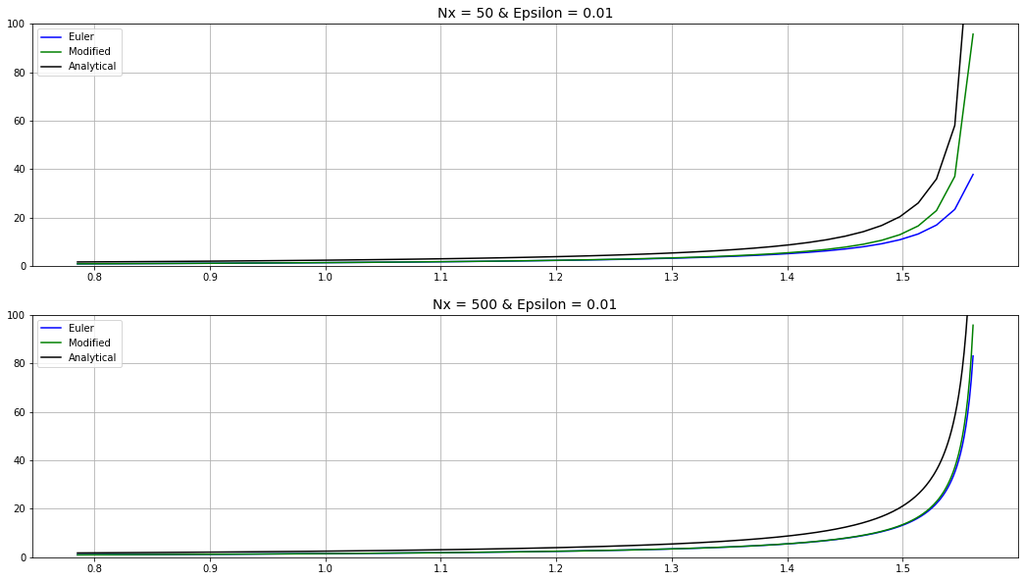

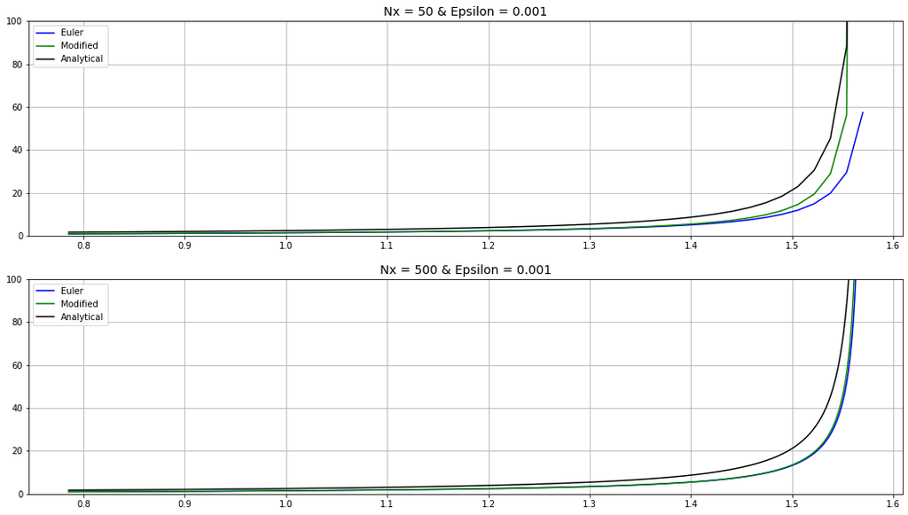

[output not shown]

```python
# define interval, with epsilon to avoid "blowing up"
epsilon=0.01
xmin= np.pi/4
xmax= np.pi/2-epsilon
Nx = 50
x = np.linspace(xmin,xmax,Nx)
uf0 = 1.0
#define dydx
def ff(x,y):
    dydx = y*np.tan(x)+np.sin(x)
    return dydx

# Define Euler's method
def euler(Nx, xmin, xmax, uf0):
    #Diff eqn of form: d(uf)/dx=ff(x,uf)
    #Nx: Number of points to be used for integration
    #xmin, xmax: Initial and final values of the independent variable (x)
    #uf0: Initial value of the dependent variable at x=xmin

    #Assume the function f(u,x) is of form:

    #ff(x[n], uf[n])

    #For any function f(u,x) on the RHS, you need to provide (define it outside of this euler() function, in a separate cell)
    #a python function. For example, for the eigenfunction problem:
    #Define x
    x = np.linspace(xmin, xmax, Nx)
    #Calculate dx
    dx = x[1] - x[0]
    #Set up the array for ux
    uf = np.zeros(Nx)
    #Define the initial condition
    uf[0] = uf0

    #We need to write another function ff(x[n],uf[n])
    #for the integrand. We will do it later when we need to
    #solve the equation for particular cases.
    for n in range(Nx - 1):
        #Fill in the code for uf[n+1]
        #--------------------------------------
        uf[n+1] = uf[n] + dx * ff(x[n], uf[n])
        #--------------------------------------
    return uf
# Define modified Euler's method
def mod_euler(Nx, xmin, xmax, uf0):
    #Diff eqn of form: d(uf)/dx=ff(x,uf)
    #Nx: Number of points to be used for integration
    #xmin, xmax: Initial and final values of the independent variable (x)
    #uf0: Initial value of the dependent variable at x=xmin

    #Define x
    x = np.linspace(xmin, xmax, Nx)
    #Determine dx
    dx = x[1] - x[0]
    #Set up the array for ux and initialize it to zero
    uf = np.zeros(Nx)
    #Specify the boundary (initial) condition at x=xmin
    uf[0] = uf0

    for n in range(Nx - 1):
        # uf[n+1] is of the form: uf[n+1] = uf[n] + 0.5 * dx * (ff1 + ff2)
        #Write in the code for ff1 and ff2
        #--------------------------------------
        ff1 = ff(x[n], uf[n])
        ff2 = ff(x[n+1], uf[n] + dx * ff(x[n], uf[n]))
        #--------------------------------------------
        uf[n+1] = uf[n] + 0.5 * dx * (ff1 + ff2)
    return uf

# Define Exact Solution
def exact(x):
    yx= (5-np.cos(2*x))/(4*np.cos(x))
    return yx
# lets take a look at how changing the value of Nx changes the plots. Lets try the extreme values (50 and 500)

#look at situation when Nx=50
Euler50 = euler(Nx, xmin, xmax, uf0)
Modified50 = mod_euler(Nx, xmin, xmax, uf0)
Analytical50 = exact(x)
fig, ax = plt.subplots(2,1, figsize=(18,10))
ax[0].plot(x,Euler50,"b")
ax[0].plot(x,Modified50,"g")
ax[0].plot(x,Analytical50,"k")
ax[0].grid(True)
ax[0].set_title('Nx = 50 & Epsilon = 0.01', fontsize=14);

#look at situation when Nx = 500
Nx=500 #redefine Nx
x = np.linspace(xmin,xmax,Nx)
Euler500 = euler(Nx, xmin, xmax, uf0)
Modified500 = mod_euler(Nx, xmin, xmax, uf0)
Analytical500=exact(x)
ax[1].plot(x,Euler500,"b")
ax[1].plot(x,Modified500,"g")
ax[1].plot(x,Analytical500,"k")
ax[1].grid(True)
ax[1].set_title('Nx = 500 & Epsilon = 0.01', fontsize=14);
ax[0].set_ylim([0,100])
ax[1].set_ylim([0,100])
ax[0].legend(["Euler","Modified","Analytical"])
ax[1].legend(["Euler","Modified","Analytical"])
plt.show()

# now lets take a look at how changing Epsilon changes the plots. Lets make both plots again but with Epsilon 0.001 not 0.01
epsilon=0.001 # note the change in epsilon
xmin= np.pi/4
xmax= np.pi/2-epsilon
Nx = 50 #redefine Nx here
x = np.linspace(xmin,xmax,Nx)
Eulerepsilon50 = euler(Nx, xmin, xmax, uf0)
Modifiedepsilon50 = mod_euler(Nx, xmin, xmax, uf0)
Analyticalepsilon50 = exact(x)
fig, bx = plt.subplots(2,1, figsize=(18,10))
bx[0].plot(x,Eulerepsilon50,"b")
bx[0].plot(x,Modifiedepsilon50,"g")
bx[0].plot(x,Analyticalepsilon50,"k")
bx[0].grid(True)
bx[0].set_title('Nx = 50 & Epsilon = 0.001', fontsize=14);
bx[0].legend(["Euler","Modified","Analytical"])
Nx = 500 #redefine Nx here
x = np.linspace(xmin,xmax,Nx)
Eulerepsilon500 = euler(Nx, xmin, xmax, uf0)
Modifiedepsilon500 = mod_euler(Nx, xmin, xmax, uf0)
Analyticalepsilon500 = exact(x)
bx[1].plot(x,Eulerepsilon500,"b")
bx[1].plot(x,Modifiedepsilon500,"g")
bx[1].plot(x,Analyticalepsilon500,"k")
bx[1].grid(True)
bx[0].set_ylim([0,100])
bx[1].set_ylim([0,100])
bx[1].set_title('Nx = 500 & Epsilon = 0.001', fontsize=14);
bx[1].legend(["Euler","Modified","Analytical"])
plt.show()
print("From adjusting the values for Nx, I notice that both the modified Euler's and the Euler's method are significantly closer to the actual function when Nx = 500 compared to when Nx = 50, but this comes at computational cost, since Nx = 500 requires 10x more points. As for epsilon, decreasing its value from 0.01 to 0.001 did make the approximations slightly more accurate, but the change was not nearly as profound as when Nx was changed. As expected, the estimations come closest to the actual function when Nx is highest and epsilon is lowest, and the modified Euler's method is closer to the actual function than the regular Euler's method. The two methods are quite far apart in my first graph, which is when Nx = 50 and when epsilon = 0.01, but the two methods are quite close together in my last graph, which is when Nx = 500 and when epsilon = 0.001. With all of this information put together, I conclude that if I did not have the anlytical solution to a problem and I was not limited by computing power, I would use the modified Euler's method with as many points as needed (this depends on how linear the unknown solution is) and an epsilon as small as possible.")
```

## Problem 2

#### Expand the SIR epidemic model to include an additional compartment, that of the Exposed (E) population.

In many contagious diseases there is a significant incubation period during which individuals have been infected but are not yet infectious themselves. This delay between the acquisition of infection and the infectious state can be included within the SIR model by adding an exposed population (compartment), E, and letting the infected (but not yet infectious) individuals move from the susceptible population (S) to E and from E to I (Infectious). This expanded model is called SEIR.

Assume a closed population with no births or deaths (that is, the overall population, N, remains constant). The differential equations describing this model are:

$$ \frac{dS}{dt} = - \beta I \frac{S}{N} $$$$ \frac{dE}{dt} = \beta I \frac{S}{N} - \sigma E$$$$ \frac{dI}{dt} = \sigma E - \gamma I $$$$ \frac{dR}{dt} = \gamma I $$

where $1 / \sigma$ is the average incubation period (that is, the average time of remaining in compartment E), and all other constants and variables have their usual meaning.

a) Solve the system of differential equations of the SEIR model for incubation period $1/\sigma = 2$ days, and for incubation period $1/\sigma = 5$ days. The numerical values of the other parameters can be obtained from the examples solved in the Lecture or the Lab.

b) Plot the time evolution (for 200 days) of the epidemic for all populations (S, E, I, R) in one graph, and comment on the results.

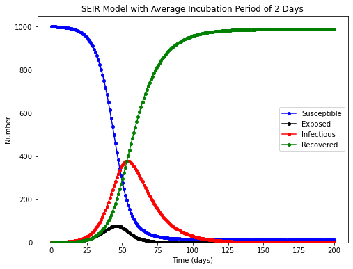

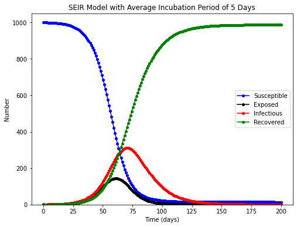

[output not shown]

```python
# Total population (N) and number of days (Ndays) of epidemic duration
N = 1000
Ndays=200

# Contact rate (beta), mean recovery rate (gamma,in 1/days), and incubation period (1/sigma)
beta = 0.3
gamma = 1.0/14
sigma=1/2

# Generating the time array:
t = np.linspace(0, Ndays, Ndays)
dt=t[1]-t[0]

# Initializing the S,E, I, R arrays
S=np.zeros(Ndays)
E=np.zeros(Ndays)
I=np.zeros(Ndays)
R=np.zeros(Ndays)

# start with one infected individual
S[0]=N
E[0]=0
I[0]=1
R[0]=0

# Solving the system of differential equations
for n in range(Ndays-1):
    S[n+1]=S[n]+dt*(-beta*S[n]*I[n]/N)
    E[n+1]=E[n]+dt*(beta*I[n]*S[n]/N-sigma*E[n])
    I[n+1]=I[n]+dt*(sigma*E[n] - gamma*I[n])
    R[n+1]=R[n]+dt*(gamma*I[n])


# Plotting the results (disease trajectory)
fig=plt.figure(figsize=(8,6))
plt.plot(t,S,'bo-',ms=4,label='Susceptible')
plt.plot(t,E,'ko-',ms=4,label='Exposed')
plt.plot(t,I,'ro-',ms=4,label='Infectious')
plt.plot(t,R,'go-',ms=4,label='Recovered')

plt.xlabel('Time (days)')
plt.ylabel('Number')
plt.ylim(0,01.05*N)
plt.legend(loc='center right')
plt.title("SEIR Model with Average Incubation Period of 2 Days")
plt.show()

#change average incubation period to 5 days
sigma=1/5

#repeat previous steps

# Initializing the S,E, I, R arrays
S=np.zeros(Ndays)
E=np.zeros(Ndays)
I=np.zeros(Ndays)
R=np.zeros(Ndays)

# start with one infected individual
S[0]=N
E[0]=0
I[0]=1
R[0]=0

# Solving the system of differential equations
for n in range(Ndays-1):
    S[n+1]=S[n]+dt*(-beta*S[n]*I[n]/N)
    E[n+1]=E[n]+dt*(beta*I[n]*S[n]/N-sigma*E[n])
    I[n+1]=I[n]+dt*(sigma*E[n] - gamma*I[n])
    R[n+1]=R[n]+dt*(gamma*I[n])


# Plotting the results (disease trajectory)
fig=plt.figure(figsize=(8,6))
plt.plot(t,S,'bo-',ms=4,label='Susceptible')
plt.plot(t,E,'ko-',ms=4,label='Exposed')
plt.plot(t,I,'ro-',ms=4,label='Infectious')
plt.plot(t,R,'go-',ms=4,label='Recovered')

plt.xlabel('Time (days)')
plt.ylabel('Number')
plt.ylim(0,01.05*N)
plt.legend(loc='center right')
plt.title("SEIR Model with Average Incubation Period of 5 Days")
plt.show()
print("As you can see from the graphs above, when the average incubation period equals 5, the peak of the infectious curve occurs later, the infectious curve is wider, and peaks at a lower number. Furthermore, the exposed curve peaks later and to a higher point when the average incubation period is 5 days. Howver, in both cases, almost everyone gets infected with the disease.")
```

## Problem 3

File `AM10_Hawaii_Covid-19_daily_cases` contains reported daily data of Covid-19 infected cases in the State of Hawaii from the onset of the exponential growth of the first wave up to November 2, 2020. Use this dataset to perform the following tasks:

a) Load and plot the data.

b) In this problem, you will work with the first month of data (first 30 days, corresponding to the first epidemic wave, which occured in Spring 2020): slice the data array appropriately.

c) Fit this data with a "difference of sigmoids" fitting function (which has been discussed in Lab and Section), considering that the sigmoid parameter $\alpha$ takes the constant value $\alpha = 0.25$. Determine the value of the parameter $\Delta t$, and calculate the RMSE of the fit. Discuss the value of the estimated parameter $\Delta t$.

d) Estimate the total number of cases expected to occur (in the first wave) till the number of cases drops to near zero (that is, the total number of cases from the onset of the wave till its decay). Compare with the actual total number of cases.

OPTIONAL:

e) Repeat parts b), c), and d), but for 7-day moving average values.

Note: In order to smooth-out the values of dataset, 7-day moving average values are used instead of the daily values. You can transform the original dataset to a 7-day average dataset by replacing each daily value with the average of the values of the prior 7 days (including the current value). You may "lose" the first six values of your dataset, but you'll get the advantage of working with smoothed data.

```
PART A
```

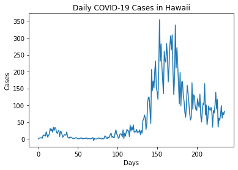

```
PART B
```

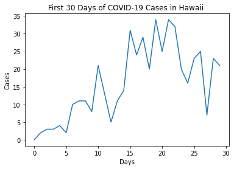

```
PART C
Number of variables used = 3
RMSE = [5.64285536]
```

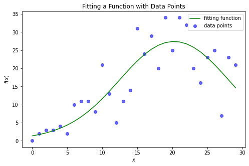

```
With the value of 14.261 for delta t, it means that the estimated time that a person is infected is around 14 days

PART D
```

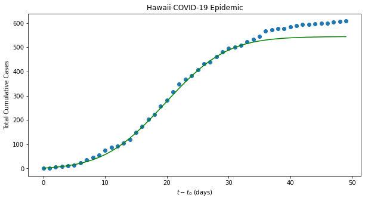

```
The estimated cumulative cases in the first wave is  538, Remaining days until near zero cases = 10
The end of the first wave is estimated to occur 40 days after the first case
From the data, the total number of cases in the first wave is  578.0 which is higher than the 538 value I estimated with my fit, which means this model underestimates the cases in this situation

PART E

Part B Repeated with 7 day average
```

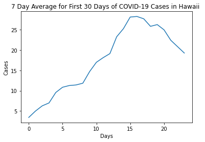

```
Part C Repeated with 7 day average

Number of variables used = 3
RMSE = [1.49900308]
```

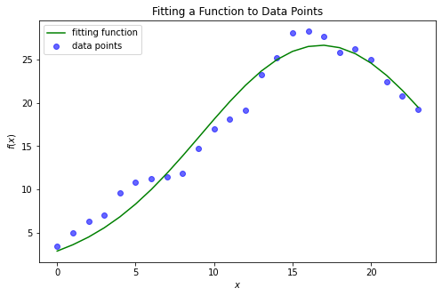

```
With the value of 13.855 for delta t, it means that the estimated time that a person is infected is around 14 days

Part D Repeated with 7 day average
```

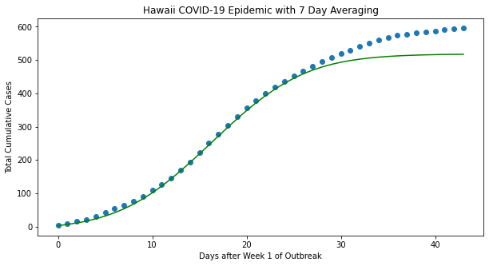

```
The estimated cumulative case count in the first wave is  512, Remaining days until near zero cases = 12
The end of the first wave is estimated to occur 42 days after the first case
From the actual data, the total number of cumulative cases in the first 42 days is 588.0 which is higher than the value I estimated using the fit line for the 7 day averaged data, meaning this fit line underestimates the amount of cases in the first wave
```

```python
print('PART A')
hdc=np.loadtxt("AM10_Hawaii_Covid-19_daily_cases.txt")
plt.plot(hdc)
plt.title("Daily COVID-19 Cases in Hawaii")
plt.ylabel("Cases")
plt.xlabel("Days")
plt.show()
print('PART B')
first_thirty=hdc[:30] #first 30 entries of data
plt.plot(first_thirty)
plt.xlabel("Days")
plt.ylabel("Cases")
plt.title("First 30 Days of COVID-19 Cases in Hawaii ")
plt.show()
print('PART C')
#fit using the difference of two sigmoids
#define alpha
alpha1=0.25
alpha2=0.25
#define sigmoid
def sigmoid(a,t0,t):
    return 1/(1+np.exp(-a*(t-t0)))

def fit_and_plot_func(func, x, y, title): #define fit and plot function
    # first find the coefficients
    popt, pcov = curve_fit(func, x, y)
    num_vars = len(popt)
    print(f'Number of variables used = {num_vars}')

    # Plot the polynomial
    ffit=func(x,*popt)

    # calculate the rmse
    Nd=np.shape(x)
    ovrNd=(1.0/np.sqrt(Nd))
    rmsefit=ovrNd*np.sqrt(np.sum((ffit-y)**2))

    print(f'RMSE = {rmsefit}')
    plt.figure(figsize=(8,5))
    plt.title(title)
    plt.scatter(x,y, facecolor = 'blue', alpha = 0.6, label='data points')

    plt.plot(x,ffit,'g', label='fitting function')
    plt.xlabel(r'$x$')
    plt.ylabel(r'$f(x)$')
    plt.legend()
    plt.show();

#define fit
def daily_fit(t,t1,dt,N2):
    t01 = t1
    t02 = t01 + dt
    return N2*(sigmoid(alpha1,t01,t)-sigmoid(alpha2,t02,t))
#create an array for the first thirty days
xdat=np.arange(0,30,1)
sigmoidfit=fit_and_plot_func(daily_fit,xdat,first_thirty,"Fitting a Function with Data Points")
popt, pcov = curve_fit(daily_fit,xdat,first_thirty) #return coeffs.
# assign values to parameters returned in popt (optimal parameters)
t1= popt[0]
dt=popt[1]
N2=popt[2]
ffit=daily_fit(xdat,t1,dt,N2) #use optimal parameters to generate fitted data
print("With the value of", np.round(dt,3),"for delta t, it means that the estimated time that a person is infected is around 14 days")
print()
print('PART D')
fdat=hdc[:50] #going to now look at first 50 entries, since there seems to be a dip in cases there
T_ext=20 # need to extend from 30 to 50
xdat_ext = np.arange(len(xdat)+T_ext) # extend x data
ffit_ext = daily_fit(xdat_ext,t1,dt,N2) #extend fit data
cumm_fit=np.zeros(len(xdat)+T_ext) #initialze cumulative cases for the fit
cumm_fit[0]=ffit[0] # assign first value
cumm_dat=np.zeros(len(fdat)) #initialze cumulative cases for the actual data
cumm_dat[0]=fdat[0] # assign first value
for i in range(1,len(fdat)): #use for loop to calculate estimated cumulative cases
    cumm_dat[i]=cumm_dat[i-1]+fdat[i]
for i in range(1,len(xdat)+T_ext): #use for loop to calculate actual cumulative cases
    cumm_fit[i]=cumm_fit[i-1]+ffit_ext[i]
fig=plt.figure(figsize=(10,5))
plt.scatter(xdat_ext,cumm_dat)
plt.plot(xdat_ext,cumm_fit,'g')
plt.title("Hawaii COVID-19 Epidemic")
plt.ylabel('Total Cumulative Cases')
plt.xlabel('$t-t_0$ (days)')
plt.show()
Nt=cumm_fit[-1] #cumulative cases at the end of the fit
Ncut=0.99*Nt
for i in range (len(xdat_ext)):
    if cumm_fit[i] > Ncut:
        imax=i
        break
# calculate cumulative cases at the estimated end of the first wave by indexing to imax and find remaining days by subtracting current days
print(f'The estimated cumulative cases in the first wave is  {int(cumm_fit[imax])}, Remaining days until near zero cases = {imax-len(xdat)}')
print("The end of the first wave is estimated to occur",imax, "days after the first case")
print('From the data, the total number of cases in the first wave is ',np.sum(hdc[:40]),'which is higher than the 538 value I estimated with my fit, which means this model underestimates the cases in this situation')
print()
print('PART E')
print()
print('Part B Repeated with 7 day average')
numbers=hdc[:30]
window_size=7 #set our window to 7 days
i=0 #start with index 0
moving_averages=[]
while i < len(numbers) - window_size + 1: #use while loop to calculate moving 7 day average
    this_window = numbers[i : i + window_size] # index for this window
    window_average = sum(this_window) / window_size #calculate average for this window
    moving_averages.append(window_average) #append empty array from before loop
    i += 1 # increase i by one
plt.plot(moving_averages)
plt.xlabel("Days")
plt.ylabel("Cases")
plt.title("7 Day Average for First 30 Days of COVID-19 Cases in Hawaii ")
plt.show()
print('Part C Repeated with 7 day average')
print()
xdat_7=np.arange(len(moving_averages)) #generate an array for appropriate size in steps of 1
sigmoidfit=fit_and_plot_func(daily_fit,xdat_7,moving_averages,"Fitting a Function to Data Points")
popt, pcov = curve_fit(daily_fit,xdat_7,moving_averages) # use new data but same idea as before
t1= popt[0]
dt=popt[1]
N2=popt[2]
ffit_7=daily_fit(xdat_7,t1,dt,N2)
print("With the value of", np.round(dt,3),"for delta t, it means that the estimated time that a person is infected is around 14 days")
print()
print('Part D Repeated with 7 day average')
numbers=hdc[:50] # go up to index 50
window_size=7 #same idea as before
i=0
moving_averages=[]
while i < len(numbers) - window_size + 1:
    this_window = numbers[i : i + window_size]
    window_average = sum(this_window) / window_size
    moving_averages.append(window_average)
    i += 1
fdat_7= moving_averages #moving 7 day averages, should have size 24
T_ext=20 #extend by 20 days again
xdat_ext_7 = np.arange(len(xdat_7)+T_ext) # all of this follows same principles from above
ffit_ext_7 = daily_fit(xdat_ext_7,t1,dt,N2)
cumm_fit_7=np.zeros(len(xdat_7)+T_ext)
cumm_fit_7[0]=ffit_7[0]
cumm_dat_7=np.zeros(len(fdat_7))
cumm_dat_7[0]=fdat_7[0]
for i in range(1,len(fdat_7)):
    cumm_dat_7[i]=cumm_dat_7[i-1]+fdat_7[i]
for i in range(1,len(xdat_7)+T_ext):
    cumm_fit_7[i]=cumm_fit_7[i-1]+ffit_ext_7[i]
fig=plt.figure(figsize=(10,5))
plt.scatter(xdat_ext_7,cumm_dat_7)
plt.plot(xdat_ext_7,cumm_fit_7,'g')
plt.title("Hawaii COVID-19 Epidemic with 7 Day Averaging")
plt.ylabel('Total Cumulative Cases')
plt.xlabel('Days after Week 1 of Outbreak')
plt.show()
Nt_7=cumm_fit_7[-1]
Ncut_7=0.99*Nt_7
for i in range (len(xdat_ext_7)):
    if cumm_fit_7[i] > Ncut_7:
        imax_7=i
        break
print(f'The estimated cumulative case count in the first wave is  {int(cumm_fit_7[imax_7])}, Remaining days until near zero cases = {imax_7-len(xdat_7)}')
print("The end of the first wave is estimated to occur", imax_7+6, "days after the first case") # add 6 to account for the first 6 days "lost"
#sum the first 42 of days data from originial text file to compare
print("From the actual data, the total number of cumulative cases in the first 42 days is",np.sum(hdc[:42]),"which is higher than the value I estimated using the fit line for the 7 day averaged data, meaning this fit line underestimates the amount of cases in the first wave")
```